# Tugas Akhir Anreg

## Plot Sisaan Vs Y duga

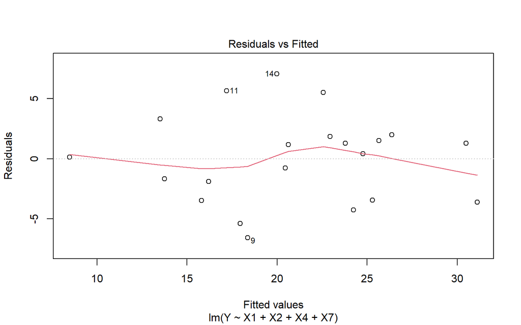

```r
plot(model,1)
```

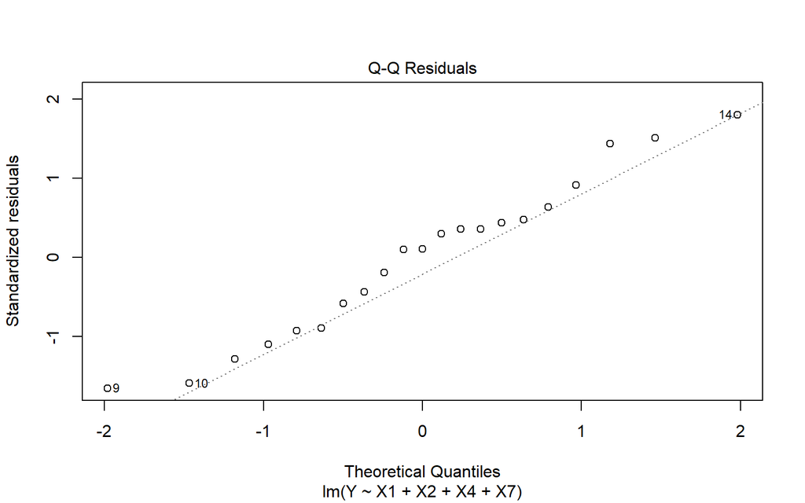

```r
plot(model,2)
```

## Plot Sisaan Vs Urutan

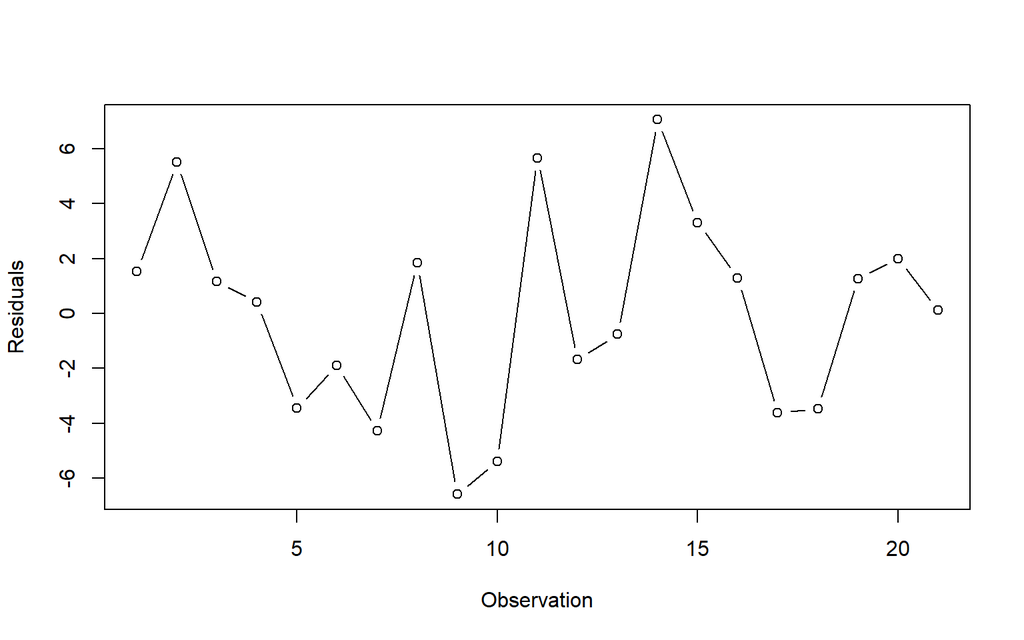

```r
plot(x = 1:dim(dt2)[1],
     y = model$residuals,
     type = 'b',
     ylab = "Residuals",
     xlab = "Observation")
```

## Kondisi Gaus Markov

### 1. Nilai Harapan Sisaan sama dengan Nol

H0: Nilai harapan sisaan sama dengan nol  
H1: Nilai harapan sisaan tidak sama dengan nol

```r
t.test(model$residuals,mu = 0,conf.level = 0.95)
```

```
##
##  One Sample t-test
##
## data:  model$residuals
## t = -6.6554e-18, df = 20, p-value = 1
## alternative hypothesis: true mean is not equal to 0
## 95 percent confidence interval:
##  -1.681668  1.681668
## sample estimates:
##    mean of x
## -5.36551e-18
```

### 2. Ragam Sisaan Homogen

$H0:var[e]=sigma2I$ (ragam sisan homogen)  
$H1:var[e] != sigma2I$ (ragam siaan tidak homogen)

```r
bptest(model)
```

```
##
##  studentized Breusch-Pagan test
##
## data:  model
## BP = 2.3095, df = 4, p-value = 0.679
```

### 3. Sisaan Saling Bebas

$H0:E[ei,ej]=0$ (sisaan saling bebas/tidak ada autokorelasi)  
$H1:E[ei,ej] != 0$ (sisaan tidak saling bebas/ada autokorelasi)

```r
dwtest(model)
```

```
##
##  Durbin-Watson test
##
## data:  model
## DW = 1.7442, p-value = 0.2495
## alternative hypothesis: true autocorrelation is greater than 0
```

## Uji Formal Normalitas Sisaan

$H_0 : N$ (sisaan menyebar Normal) $H_1 : N$ (sisaan tidak menyebar Normal)

```r
shapiro.test(model$residuals)
```

```
##
##  Shapiro-Wilk normality test
##
## data:  model$residuals
## W = 0.9723, p-value = 0.7834
```